# DS2 Lab4 - Neural nets

Data Science 2: Machine Learning Tools - CEU 2021

Janos K. Divenyi, Jeno Pal

2020-03-22

```r
library(tidyverse)
library(caret)
theme_set(theme_minimal())

my_seed <- 20210322
```

## Neural nets with `caret`

Very large number of parameters: regularization is needed. Done via ideas similar to ridge or lasso. (Hence it is a good idea to center and scale features and remove correlated features / de-correlate them. Concrete example here: many binary features, then it may not help much).

Also, typically local solutions are found: initialization from many random starting values and model averaging can help.

```r
# the famous german credit data
# downloaded in friendly form from
# https://github.com/stedy/Machine-Learning-with-R-datasets/blob/master/credit.csv
data <- read_csv("https://raw.githubusercontent.com/stedy/Machine-Learning-with-R-datasets/master/credit.csv")
skimr::skim(data)
```

Data summary

| Name | data |
| --- | --- |
| Number of rows | 1000 |
| Number of columns | 21 |
| _______________________ |  |
| Column type frequency: |  |
| character | 13 |
| numeric | 8 |
| ________________________ |  |
| Group variables | None |

**Variable type: character**

| skim_variable | n_missing | complete_rate | min | max | empty | n_unique | whitespace |
| --- | --- | --- | --- | --- | --- | --- | --- |
| checking_balance | 0 | 1 | 6 | 10 | 0 | 4 | 0 |
| credit_history | 0 | 1 | 6 | 22 | 0 | 5 | 0 |
| purpose | 0 | 1 | 6 | 19 | 0 | 10 | 0 |
| savings_balance | 0 | 1 | 7 | 13 | 0 | 5 | 0 |
| employment_length | 0 | 1 | 7 | 10 | 0 | 5 | 0 |
| personal_status | 0 | 1 | 6 | 13 | 0 | 4 | 0 |
| other_debtors | 0 | 1 | 4 | 12 | 0 | 3 | 0 |
| property | 0 | 1 | 5 | 24 | 0 | 4 | 0 |
| installment_plan | 0 | 1 | 4 | 6 | 0 | 3 | 0 |
| housing | 0 | 1 | 3 | 8 | 0 | 3 | 0 |
| telephone | 0 | 1 | 3 | 4 | 0 | 2 | 0 |
| foreign_worker | 0 | 1 | 2 | 3 | 0 | 2 | 0 |
| job | 0 | 1 | 16 | 23 | 0 | 4 | 0 |

**Variable type: numeric**

| skim_variable | n_missing | complete_rate | mean | sd | p0 | p25 | p50 | p75 | p100 | hist |
| --- | --- | --- | --- | --- | --- | --- | --- | --- | --- | --- |
| months_loan_duration | 0 | 1 | 20.90 | 12.06 | 4 | 12.0 | 18.0 | 24.00 | 72 | ▇▇▂▁▁ |
| amount | 0 | 1 | 3271.26 | 2822.74 | 250 | 1365.5 | 2319.5 | 3972.25 | 18424 | ▇▂▁▁▁ |
| installment_rate | 0 | 1 | 2.97 | 1.12 | 1 | 2.0 | 3.0 | 4.00 | 4 | ▂▃▁▂▇ |
| residence_history | 0 | 1 | 2.85 | 1.10 | 1 | 2.0 | 3.0 | 4.00 | 4 | ▂▆▁▃▇ |
| age | 0 | 1 | 35.55 | 11.38 | 19 | 27.0 | 33.0 | 42.00 | 75 | ▇▆▃▁▁ |
| existing_credits | 0 | 1 | 1.41 | 0.58 | 1 | 1.0 | 1.0 | 2.00 | 4 | ▇▅▁▁▁ |
| default | 0 | 1 | 1.30 | 0.46 | 1 | 1.0 | 1.0 | 2.00 | 2 | ▇▁▁▁▃ |
| dependents | 0 | 1 | 1.16 | 0.36 | 1 | 1.0 | 1.0 | 1.00 | 2 | ▇▁▁▁▂ |

```r
data <- mutate(data, default = factor(ifelse(default == 2, "Yes", "No"), levels = c("Yes", "No")))
summarize(data, default_probability = mean(default == "Yes"))
```

| default_probability |
| --- |
| 0.3 |

```r
# turn character variables to factors
data <- mutate(data, across(where(is.character), as.factor))
```

```r
training_ratio <- 0.75
set.seed(my_seed)
train_indices <- createDataPartition(
  y = data[["default"]],
  times = 1, p = training_ratio, list = FALSE
) %>% as.vector()
data_train <- data[train_indices, ]
data_test <- data[-train_indices, ]
```

```r
train_control <- trainControl(
  method = "cv",
  number = 5,
  classProbs = TRUE,
  summaryFunction = twoClassSummary
)
```

```r
# baseline logistic model
set.seed(my_seed)
glm_model <- train(
  default ~ .,
  method = "glm",
  data = data_train,
  trControl = train_control,
  metric = "ROC"
)
glm_model
```

```
## Generalized Linear Model
##
## 750 samples
##  20 predictor
##   2 classes: 'Yes', 'No'
##
## No pre-processing
## Resampling: Cross-Validated (5 fold)
## Summary of sample sizes: 600, 600, 600, 600, 600
## Resampling results:
##
##   ROC        Sens       Spec
##   0.7680847  0.4933333  0.847619
```

```r
confusionMatrix(glm_model)
```

```
## Cross-Validated (5 fold) Confusion Matrix
##
## (entries are percentual average cell counts across resamples)
##
##           Reference
## Prediction  Yes   No
##        Yes 14.8 10.7
##        No  15.2 59.3
##
##  Accuracy (average) : 0.7413
```

Size: number of units in the hidden layer. Decay: regularization parameter.

```r
tune_grid <- expand.grid(
  size = c(3, 5, 7, 10, 15),
  decay = c(0.1, 0.5, 1, 1.5, 2, 2.5, 5)
)

set.seed(my_seed)
nnet_model <- train(
  default ~ .,
  method = "nnet",
  data = data_train,
  trControl = train_control,
  tuneGrid = tune_grid,
  # decay: regularization, has to center and scale like with Ridge, Lasso
  # PCA: correlated variables are problematic for gradient-based optimization
  preProcess = c("center", "scale", "pca"),
  metric = "ROC",
  # avoid extensive iteration output
  trace = FALSE
)
nnet_model
```

```
## Neural Network
##
## 750 samples
##  20 predictor
##   2 classes: 'Yes', 'No'
##
## Pre-processing: centered (48), scaled (48), principal component
##  signal extraction (48)
## Resampling: Cross-Validated (5 fold)
## Summary of sample sizes: 600, 600, 600, 600, 600
## Resampling results across tuning parameters:
##
##   size  decay  ROC        Sens       Spec
##    3    0.1    0.7048889  0.4933333  0.7809524
##    3    0.5    0.7280423  0.4488889  0.8266667
```

[output cut: 36 more lines]

```r
nnet_model$finalModel
```

```
## a 38-10-1 network with 401 weights
## inputs: PC1 PC2 PC3 PC4 PC5 PC6 PC7 PC8 PC9 PC10 PC11 PC12 PC13 PC14 PC15 PC16 PC17 PC18 PC19 PC20 PC21 PC22 PC23 PC24 PC25 PC26 PC27 PC28 PC29 PC30 PC31 PC32 PC33 PC34 PC35 PC36 PC37 PC38
## output(s): .outcome
## options were - entropy fitting  decay=2
```

```r
confusionMatrix(nnet_model)
```

```
## Cross-Validated (5 fold) Confusion Matrix
##
## (entries are percentual average cell counts across resamples)
##
##           Reference
## Prediction  Yes   No
##        Yes 12.8  8.4
##        No  17.2 61.6
##
##  Accuracy (average) : 0.744
```

```r
glm_prediction <- predict(glm_model, newdata = data_test, type = "prob")$Yes
nnet_prediction <- predict(nnet_model, newdata = data_test, type = "prob")$Yes
# to calculate AUC on the test set, we need the pROC package
pROC::auc(pROC::roc(data_test$default, glm_prediction))
```

```
## Area under the curve: 0.812
```

```r
pROC::auc(pROC::roc(data_test$default, nnet_prediction))
```

```
## Area under the curve: 0.7952
```

### Evaluate classification models trained by caret (ROC)

We can create ROC curve from `caret` models as well.

```r
# First, replicate Confusion Matrix
cm <- table(
  factor(ifelse(nnet_prediction > 0.5, "Yes", "No"), levels = c("Yes", "No")),
  data_test$default,
  dnn = c("prediction", "reference")
)
cm
```

```
##           reference
## prediction Yes  No
##        Yes  36  24
##        No   39 151
```

```r
cm / sum(cm)
```

```
##           reference
## prediction   Yes    No
##        Yes 0.144 0.096
##        No  0.156 0.604
```

```r
# Write function to calculate CM for any cutoff
getConfusionMatrix <- function(predictions, data, cutoff = 0.5) {
  table(
    factor(ifelse(predictions > cutoff, "Yes", "No"), levels = c("Yes", "No")),
    data$default,
    dnn = c("prediction", "reference")
  )
}
getConfusionMatrix(nnet_prediction, data_test, 0.5)
```

```
##           reference
## prediction Yes  No
##        Yes  36  24
##        No   39 151
```

```r
getConfusionMatrix(nnet_prediction, data_test, 0.1)
```

```
##           reference
## prediction Yes  No
##        Yes  70 124
##        No    5  51
```

```r
# calculate FPR (1 - specificity) and TPR (sensitivity)
calculateFPRTPR <- function(confusion_matrix) {
    fpr <- confusion_matrix[1, 2] / sum(confusion_matrix[, 2])
    tpr <- confusion_matrix[1, 1] / sum(confusion_matrix[, 1])
    tibble(fpr, tpr)
}
calculateFPRTPR(getConfusionMatrix(nnet_prediction, data_test, 0.5))
```

| fpr | tpr |
| --- | --- |
| 0.1371429 | 0.48 |

```r
calculateFPRTPR(getConfusionMatrix(nnet_prediction, data_test, 0.1))
```

| fpr | tpr |
| --- | --- |
| 0.7085714 | 0.9333333 |

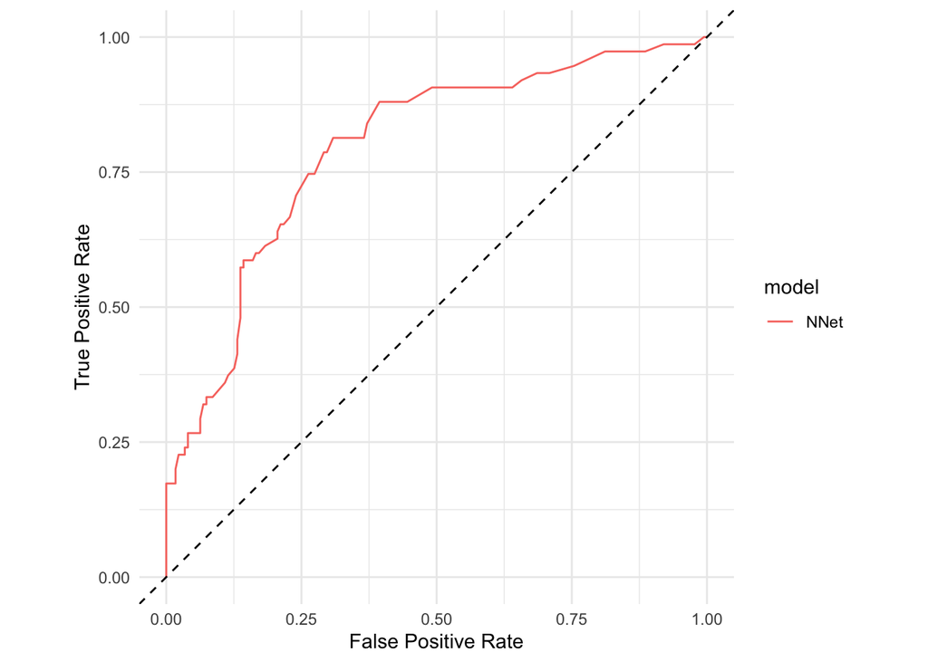

```r
data_for_roc <- map_df(
  seq(0, 1, 0.01),
  ~calculateFPRTPR(getConfusionMatrix(nnet_prediction, data_test, .x))
) %>% mutate(model = "NNet")

# recall our functions from lab "stacking"
plotROC <- function(performance_df) {
  ggplot(performance_df, aes(fpr, tpr, color = model)) +
    geom_path() +
    geom_abline(slope = 1, intercept = 0, linetype = "dashed") +
    coord_fixed() +
    labs(x = "False Positive Rate", y = "True Positive Rate")
}
plotROC(data_for_roc)
```

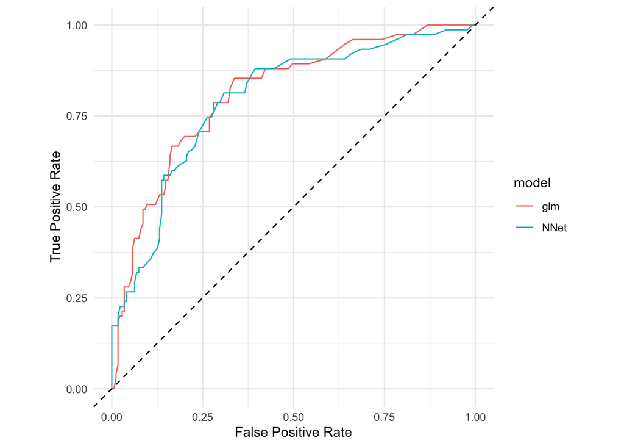

```r
# compare to glm
data_for_roc <- bind_rows(
  data_for_roc,
  map_df(
    seq(0, 1, 0.01),
    ~calculateFPRTPR(getConfusionMatrix(glm_prediction, data_test, .x))
  ) %>% mutate(model = "glm")
)
plotROC(data_for_roc)
```

### Train nets with different starting points

`nnet` with different random initial seeds. (Default: 5 initial seeds, training takes 5x times with the same grid. Parameter `repeats` controls the number of seeds.) The final result comes from averaging.

```r
# takes a long time to run for the whole grid above so we just run for one parameter set
tune_grid <- expand.grid(size = 10, decay = 2, bag = FALSE)

set.seed(my_seed)
avnnet_model <- train(
  default ~ .,
  method = "avNNet",
  data = data_train,
  repeats = 5,
  trControl = train_control,
  tuneGrid = tune_grid,
  preProcess = c("center", "scale", "pca"),
  metric = "ROC",
  trace = FALSE
)
avnnet_model
```

```
## Model Averaged Neural Network
##
## 750 samples
##  20 predictor
##   2 classes: 'Yes', 'No'
##
## Pre-processing: centered (48), scaled (48), principal component
##  signal extraction (48)
## Resampling: Cross-Validated (5 fold)
## Summary of sample sizes: 600, 600, 600, 600, 600
## Resampling results:
##
##   ROC       Sens       Spec
##   0.759746  0.3911111  0.8952381
##
## Tuning parameter 'size' was held constant at a value of 10
## Tuning
##  parameter 'decay' was held constant at a value of 2
## Tuning parameter 'bag'
##  was held constant at a value of FALSE
```

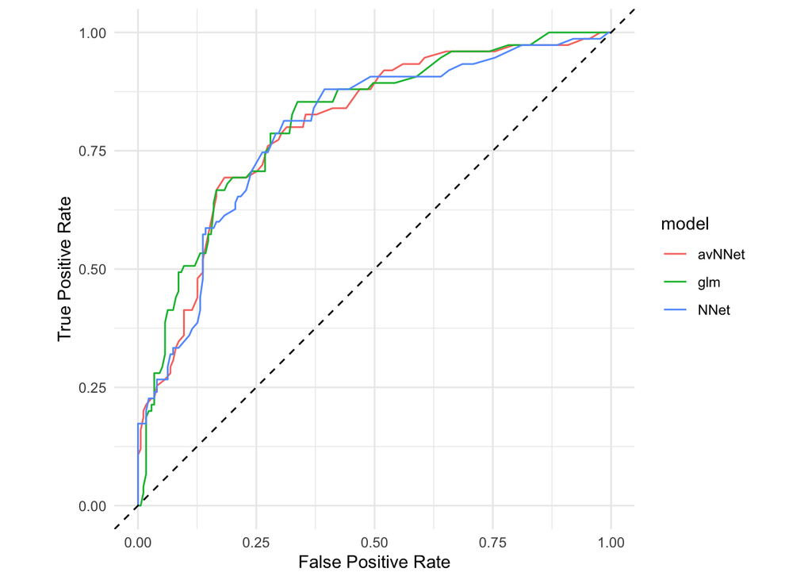

```r
avnnet_prediction <- predict(avnnet_model, newdata = data_test, type = "prob")$Yes
data_for_roc <- bind_rows(
  data_for_roc,
  map_df(
    seq(0, 1, 0.01),
    ~calculateFPRTPR(getConfusionMatrix(avnnet_prediction, data_test, .x))
  ) %>% mutate(model = "avNNet")
)
plotROC(data_for_roc)
```

## Deep learning with `h2o`

“Deep”: many layers of hidden units.

Note on estimation: when having large datasets, k-fold cross validation can become computationally burdensome, hence many times train/validation/test approach is used. (see answer on Quora by Yoshua Bengio, one of the originators of deep learning [here](https://www.quora.com/Is-cross-validation-heavily-used-in-deep-learning-or-is-it-too-expensive-to-be-used)). However, cross validation can still be used to tune some of the hyperparameters.

```r
library(h2o)
h2o.init()
```

```
##  Connection successful!
##
## R is connected to the H2O cluster:
##     H2O cluster uptime:         56 minutes 28 seconds
##     H2O cluster timezone:       Europe/Budapest
##     H2O data parsing timezone:  UTC
##     H2O cluster version:        3.32.0.4
##     H2O cluster version age:    1 month and 21 days
##     H2O cluster name:           H2O_started_from_R_jdivenyi_azw631
##     H2O cluster total nodes:    1
##     H2O cluster total memory:   7.99 GB
##     H2O cluster total cores:    8
##     H2O cluster allowed cores:  8
##     H2O cluster healthy:        TRUE
##     H2O Connection ip:          localhost
##     H2O Connection port:        54321
##     H2O Connection proxy:       NA
##     H2O Internal Security:      FALSE
##     H2O API Extensions:         Amazon S3, XGBoost, Algos, AutoML, Core V3, TargetEncoder, Core V4
##     R Version:                  R version 4.0.3 (2020-10-10)
```

```r
h2o.no_progress()
```

```r
data_split <- h2o.splitFrame(as.h2o(data_train), seed = my_seed)
data_train_h2o <- data_split[[1]]
data_valid_h2o <- data_split[[2]]
data_test_h2o <- as.h2o(data_test)

y <- "default"
X <- setdiff(names(data_train_h2o), y)
```

Validation frame: used to determine early stopping conditions. More on this later.

```r
dl_model <- h2o.deeplearning(
  x = X, y = y,
  training_frame = data_train_h2o,
  validation_frame = data_valid_h2o,
  model_id = "DL_default",
  score_each_iteration =  TRUE,  # for the purpose of illustration
  seed = my_seed
)
dl_model
```

```
## Model Details:
## ==============
##
## H2OBinomialModel: deeplearning
## Model ID:  DL_default
## Status of Neuron Layers: predicting default, 2-class classification, bernoulli distribution, CrossEntropy loss, 55,602 weights/biases, 664.3 KB, 5,660 training samples, mini-batch size 1
##   layer units      type dropout       l1       l2 mean_rate rate_rms momentum
## 1     1    74     Input  0.00 %       NA       NA        NA       NA       NA
## 2     2   200 Rectifier  0.00 % 0.000000 0.000000  0.179413 0.387740 0.000000
## 3     3   200 Rectifier  0.00 % 0.000000 0.000000  0.043539 0.119170 0.000000
## 4     4     2   Softmax      NA 0.000000 0.000000  0.001961 0.001109 0.000000
##   mean_weight weight_rms mean_bias bias_rms
## 1          NA         NA        NA       NA
## 2   -0.008014   0.089870  0.413231 0.043782
## 3   -0.006462   0.071057  0.977401 0.023696
## 4   -0.027085   0.390708 -0.000441 0.000771
##
##
## H2OBinomialMetrics: deeplearning
## ** Reported on training data. **
## ** Metrics reported on full training frame **
##
## MSE:  0.04666159
## RMSE:  0.216013
## LogLoss:  0.1719281
## Mean Per-Class Error:  0.05783312
## AUC:  0.9838938
## AUCPR:  0.968388
## Gini:  0.9677876
##
## Confusion Matrix (vertical: actual; across: predicted) for F1-optimal threshold:
##         No Yes    Error     Rate
## No     391  12 0.029777  =12/403
## Yes     14 149 0.085890  =14/163
## Totals 405 161 0.045936  =26/566
##
## Maximum Metrics: Maximum metrics at their respective thresholds
##                         metric threshold      value idx
## 1                       max f1  0.538614   0.919753 136
## 2                       max f2  0.387409   0.928144 158
```

[output cut: 43 more lines]

```
## 6                   max recall  0.000847   1.000000 170
## 7              max specificity  0.999629   1.000000   0
## 8             max absolute_mcc  0.354790   0.454866  62
## 9   max min_per_class_accuracy  0.272416   0.725806  75
## 10 max mean_per_class_accuracy  0.272416   0.735854  75
## 11                     max tns  0.999629 122.000000   0
## 12                     max fns  0.999629  61.000000   0
## 13                     max fps  0.000021 122.000000 183
## 14                     max tps  0.000847  62.000000 170
## 15                     max tnr  0.999629   1.000000   0
## 16                     max fnr  0.999629   0.983871   0
## 17                     max fpr  0.000021   1.000000 183
## 18                     max tpr  0.000847   1.000000 170
##
## Gains/Lift Table: Extract with `h2o.gainsLift(<model>, <data>)` or `h2o.gainsLift(<model>, valid=<T/F>, xval=<T/F>)`
```

```r
h2o.auc(h2o.performance(dl_model, data_test_h2o))
```

```
## [1] 0.7938286
```

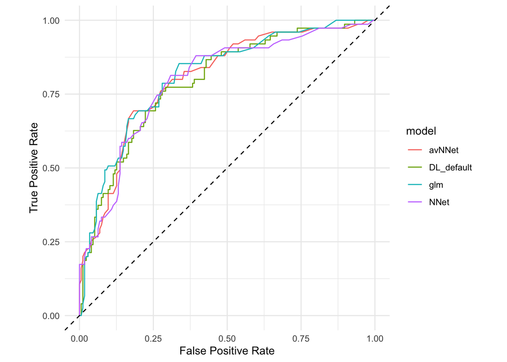

```r
# recall our function from lab "stacking"
getPerformanceMetrics <- function(model, newdata = NULL, xval = FALSE) {
  h2o.performance(model, newdata = newdata, xval = xval)@metrics$thresholds_and_metric_scores %>%
    as_tibble() %>%
    mutate(model = model@model_id)
}
dl_performance <- getPerformanceMetrics(dl_model, newdata = data_test_h2o)

bind_rows(
  data_for_roc,
  select(dl_performance, fpr, tpr, model)
) %>%
plotROC()
```

```r
h2o.scoreHistory(dl_model)
```

| timestamp | duration | training_speed | epochs | iterations | samples | training_rmse | training_logloss | training_r2 | training_auc | training_pr_auc | training_lift | training_classification_error | validation_rmse | validation_logloss | validation_r2 | validation_auc | validation_pr_auc | validation_lift | validation_classification_error |
| --- | --- | --- | --- | --- | --- | --- | --- | --- | --- | --- | --- | --- | --- | --- | --- | --- | --- | --- | --- |
| 2021-03-22 18:42:38 | 0.000 sec | NA | 0 | 0 | 0 | NaN | NaN | NaN | NaN | NaN | NaN | NaN | NaN | NaN | NaN | NaN | NaN | NaN | NaN |
| 2021-03-22 18:42:38 | 0.231 sec | 5099 obs/sec | 1 | 1 | 566 | 0.6221092 | 1.7622003 | -0.8874415 | 0.8157835 | 0.6140256 | 2.893661 | 0.24028269 | 0.5945176 | 1.7130144 | -0.58202578 | 0.7731359 | 0.5942994 | 1.483871 | 0.2880435 |
| 2021-03-22 18:42:38 | 0.402 sec | 5442 obs/sec | 2 | 2 | 1132 | 0.4000655 | 0.5847668 | 0.2194469 | 0.8214085 | 0.6737537 | 2.893661 | 0.26148410 | 0.4566653 | 0.7559110 | 0.06657351 | 0.7909836 | 0.6726573 | 2.967742 | 0.3097826 |
| 2021-03-22 18:42:38 | 0.576 sec | 5356 obs/sec | 3 | 3 | 1698 | 0.3778127 | 0.5016036 | 0.3038654 | 0.8723835 | 0.7598216 | 3.472393 | 0.18551237 | 0.4619826 | 0.8036352 | 0.04470964 | 0.8053940 | 0.6648403 | 2.967742 | 0.3043478 |
| 2021-03-22 18:42:39 | 0.712 sec | 5562 obs/sec | 4 | 4 | 2264 | 0.3681104 | 0.4393209 | 0.3391598 | 0.8689278 | 0.7440514 | 3.472393 | 0.17844523 | 0.4544162 | 0.7039397 | 0.07574517 | 0.7652036 | 0.6088280 | 1.483871 | 0.3423913 |
| 2021-03-22 18:42:39 | 0.832 sec | 5787 obs/sec | 5 | 5 | 2830 | 0.4115122 | 0.6007631 | 0.1741415 | 0.9115910 | 0.8421255 | 3.472393 | 0.14134276 | 0.4958444 | 1.0012651 | -0.10046175 | 0.8187467 | 0.6944985 | 2.967742 | 0.2336957 |
| 2021-03-22 18:42:39 | 0.971 sec | 6053 obs/sec | 6 | 6 | 3396 | 0.3909693 | 0.4889697 | 0.2545380 | 0.9118802 | 0.8317570 | 3.472393 | 0.14310954 | 0.4596849 | 0.7238321 | 0.05418866 | 0.8031465 | 0.6638306 | 2.967742 | 0.2717391 |
| 2021-03-22 18:42:39 | 1.117 sec | 6200 obs/sec | 7 | 7 | 3962 | 0.3729560 | 0.4166203 | 0.3216475 | 0.9456834 | 0.9055506 | 3.472393 | 0.09717314 | 0.4555504 | 0.6538607 | 0.07112575 | 0.8001058 | 0.6593744 | 1.483871 | 0.2663043 |
| 2021-03-22 18:42:39 | 1.319 sec | 5746 obs/sec | 8 | 8 | 4528 | 0.2767508 | 0.2557502 | 0.6264766 | 0.9530515 | 0.9157504 | 3.472393 | 0.10247350 | 0.4424094 | 0.6587094 | 0.12394197 | 0.7891327 | 0.6644480 | 2.967742 | 0.3206522 |
| 2021-03-22 18:42:39 | 1.471 sec | 5736 obs/sec | 9 | 9 | 5094 | 0.2707355 | 0.2387716 | 0.6425373 | 0.9554644 | 0.9143723 | 3.472393 | 0.09893993 | 0.4455485 | 0.6709996 | 0.11146604 | 0.8048652 | 0.6847639 | 2.967742 | 0.2391304 |

[output cut: 1 more lines]

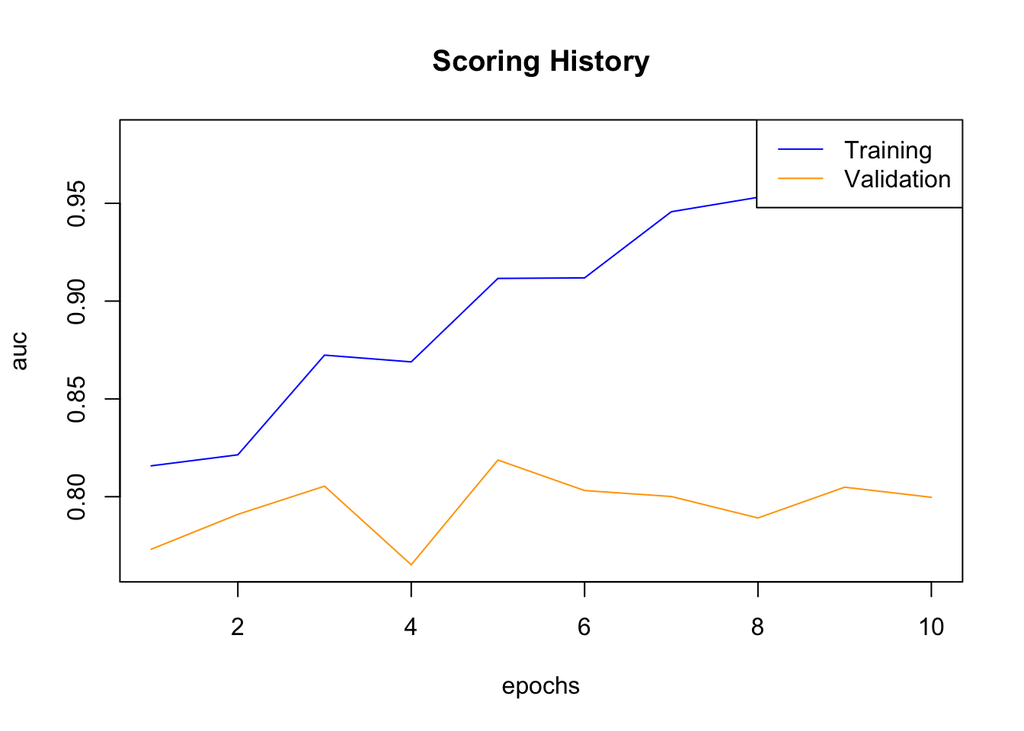

```r
plot(dl_model, metric = "AUC")
```

```r
dl_model@allparameters
```

```
## $model_id
## [1] "DL_default"
##
## $training_frame
## [1] "RTMP_sid_b755_5"
##
## $validation_frame
## [1] "RTMP_sid_b755_7"
##
## $nfolds
## [1] 0
##
## $keep_cross_validation_models
## [1] TRUE
##
## $keep_cross_validation_predictions
## [1] FALSE
##
## $keep_cross_validation_fold_assignment
## [1] FALSE
##
## $ignore_const_cols
## [1] TRUE
##
## $score_each_iteration
## [1] TRUE
##
## $balance_classes
## [1] FALSE
##
## $max_after_balance_size
## [1] 5
##
## $max_confusion_matrix_size
## [1] 20
##
## $overwrite_with_best_model
## [1] TRUE
##
## $use_all_factor_levels
```

[output cut: 184 more lines]

```
##
## $auc_type
## [1] "AUTO"
##
## $x
##  [1] "purpose"              "credit_history"       "savings_balance"
##  [4] "employment_length"    "checking_balance"     "personal_status"
##  [7] "property"             "job"                  "installment_plan"
## [10] "housing"              "other_debtors"        "foreign_worker"
## [13] "telephone"            "months_loan_duration" "amount"
## [16] "installment_rate"     "residence_history"    "age"
## [19] "existing_credits"     "dependents"
##
## $y
## [1] "default"
```

There are lots of parameters that you can change, see `?h2o.deeplearning` and the [docs](http://docs.h2o.ai/h2o/latest-stable/h2o-docs/data-science/deep-learning.html). In the followings, we look at some selected parameters.

### Network structure and functional form

- `hidden`: neuron layer architecture: length of vector shows number of layers, number shows number of neurons within layer. The default: two hidden layers with 200-200 neurons. Makes sense to experiment with shallower but more neuron or with deeper and less neurons per layer architectures.

```r
shallow_small_model <- h2o.deeplearning(
  x = X, y = y,
  model_id = "DL_shallow_small",
  training_frame = data_train_h2o,
  validation_frame = data_valid_h2o,
  hidden = c(10),
  seed = my_seed
)
```

```r
shallow_large_model <- h2o.deeplearning(
  x = X, y = y,
  model_id = "DL_shallow_large",
  training_frame = data_train_h2o,
  validation_frame = data_valid_h2o,
  hidden = c(512),
  score_each_iteration = TRUE,
  seed = my_seed
)
```

```r
deep_small_model <- h2o.deeplearning(
  x = X, y = y,
  model_id = "DL_deep_small",
  training_frame = data_train_h2o,
  validation_frame = data_valid_h2o,
  hidden = c(32, 32, 32, 32, 32),
  seed = my_seed
)
```

```r
deep_large_model <- h2o.deeplearning(
  x = X, y = y,
  model_id = "DL_deep_large",
  training_frame = data_train_h2o,
  validation_frame = data_valid_h2o,
  hidden = c(100, 100, 100),
  seed = my_seed
)
```

```r
# compare performance on test set
compareAUC <- function(list_of_models) {
  map_df(
    list_of_models,
    ~tibble(model = .@model_id, auc = h2o.auc(h2o.performance(., newdata = data_test_h2o)))
  ) %>%
  arrange(-auc)
}

dl_models <- list(dl_model, shallow_small_model, shallow_large_model, deep_small_model, deep_large_model)
compareAUC(dl_models)
```

| model | auc |
| --- | --- |
| DL_shallow_large | 0.7950476 |
| DL_default | 0.7938286 |
| DL_deep_large | 0.7895619 |
| DL_deep_small | 0.7691429 |
| DL_shallow_small | 0.7519238 |

- `activation`: the nonlinear transformative function used. Default: Rectifier. “Tanh” stands for hyperbolic tangent that is very similar to sigmoid.

```r
tanh_model <- h2o.deeplearning(
  x = X, y = y,
  model_id = "DL_tanh",
  training_frame = data_train_h2o,
  validation_frame = data_valid_h2o,
  hidden = c(512),
  activation = "Tanh",
  seed = my_seed
)
compareAUC(list(shallow_large_model, tanh_model))
```

| model | auc |
| --- | --- |
| DL_shallow_large | 0.7950476 |
| DL_tanh | 0.7680000 |

### Training samples

- `epochs`: how many times will all training data points be used to adjust the model in the course of the optimization (defaults to 10). Note: early stopping is used by default so there is no guarantee that all epochs will be used.
- `mini_batch_size`: after how many training samples is the gradient update made (defaults to 1)

```r
more_epochs_model <- h2o.deeplearning(
  x = X, y = y,
  model_id = "DL_more_epochs",
  training_frame = data_train_h2o,
  validation_frame = data_valid_h2o,
  hidden = c(512),
  epochs = 100,
  score_each_iteration = TRUE,
  seed = my_seed
)
```

```r
higher_batch_size_model <- h2o.deeplearning(
  x = X, y = y,
  model_id = "DL_higher_batch_size",
  training_frame = data_train_h2o,
  validation_frame = data_valid_h2o,
  hidden = c(512),
  mini_batch_size = 10,
  seed = my_seed
)
compareAUC(list(shallow_large_model, more_epochs_model, higher_batch_size_model))
```

| model | auc |
| --- | --- |
| DL_shallow_large | 0.7950476 |
| DL_more_epochs | 0.7242667 |
| DL_higher_batch_size | 0.7198476 |

### Regularization

You have multiple ways to regularize in a neural network. One is *“dropout”*, that “approximates training a large number of neural networks with different architectures in parallel” [source](https://machinelearningmastery.com/dropout-for-regularizing-deep-neural-networks/). Some of the nodes are randomly ignored or “dropped out” during training. Another method is to apply *penalty terms* as we did with penalized linear regressions. You can also control when the iterative optimization process should stop - with *early stopping* you can also prevent overfitting.

- `hidden_dropout_ratios`: with how large probability will neurons be left out of the model at a step (defaults to 0.5). Have to use “WithDropout” activation to use dropout.

```r
dropout_model <- h2o.deeplearning(
  x = X, y = y,
  model_id = "DL_dropout",
  training_frame = data_train_h2o,
  validation_frame = data_valid_h2o,
  hidden = c(512),
  activation = "RectifierWithDropout",
  hidden_dropout_ratios = 0.6,
  seed = my_seed
)
```

- `input_dropout_ratio`: drop some input features randomly (defaults to 0).

```r
input_dropout_model <- h2o.deeplearning(
  x = X, y = y,
  model_id = "DL_input_dropout",
  training_frame = data_train_h2o,
  validation_frame = data_valid_h2o,
  hidden = 512,
  input_dropout_ratio = 0.1,
  seed = my_seed
)
compareAUC(list(shallow_large_model, dropout_model, input_dropout_model))
```

| model | auc |
| --- | --- |
| DL_dropout | 0.8185143 |
| DL_shallow_large | 0.7950476 |
| DL_input_dropout | 0.7541333 |

For more on dropout, see the original paper [here](http://jmlr.org/papers/volume15/srivastava14a.old/srivastava14a.pdf).

- `l1`, `l2`: weight on $L1$ (lasso), $L2$ (ridge) penalty terms

```r
regularized_model <- h2o.deeplearning(
  x = X, y = y,
  model_id = "DL_regularized",
  training_frame = data_train_h2o,
  validation_frame = data_valid_h2o,
  hidden = 512,
  l1 = 0.01,
  l2 = 0.01,
  seed = my_seed
)
compareAUC(list(shallow_large_model, regularized_model))
```

| model | auc |
| --- | --- |
| DL_regularized | 0.8272762 |
| DL_shallow_large | 0.7950476 |

- early stopping options: `stopping_rounds` (defaults to 5), `stopping_metric` (defaults to “logloss” for classification and “deviance” for regression), `stopping_tolerance` (defaults to 0.001)

Training constantly tracks validation frame performance. Early stopping is enabled by default but can be tuned when to stop. This, again, is to prevent overfitting. (If you don’t supply a `validation_frame`, early stopping still works but based on metrics calculated from the training set, so it may not be as informative for out-of-sample performance.)

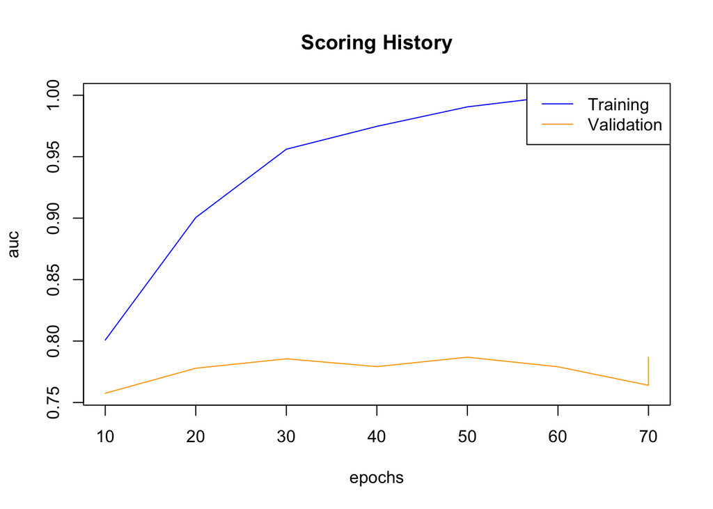

```r
early_stopping_model <- h2o.deeplearning(
  x = X, y = y,
  model_id = "DL_early_stopping",
  training_frame = data_train_h2o,
  validation_frame = data_valid_h2o,
  hidden = 512,
  score_each_iteration = TRUE,
  epochs = 100,
  stopping_rounds = 3,
  stopping_metric = "AUC",
  stopping_tolerance = 0.01,
  seed = my_seed
)
plot(early_stopping_model, metric = "AUC")
```

```r
compareAUC(list(shallow_large_model, early_stopping_model))
```

| model | auc |
| --- | --- |
| DL_shallow_large | 0.7950476 |
| DL_early_stopping | 0.7705143 |

```r
pROC::auc(pROC::roc(data_test$default, glm_prediction))
```

```
## Area under the curve: 0.812
```

The fact that our best models hardly outperformed the simple logistic regression can be explained by the nature of this data set: behavior data with a small number of observatons. Networks typically fare much better on image, text, etc. data.

## Helpful resources to deepen understanding

Videos of 3 Blue 1 Brown are awesome. Start [here](https://www.youtube.com/watch?v=aircAruvnKk&t=).